# Lecture 8: Examples

Mathematics and Statistics BS1515

Theodoros Arvanitopoulos

2025-11-21

# Importance of Standard Normal Distribution tables (Z-tables)

- Z-tables provide quick, manual lookups and build intuition about probabilities.
- Crucial for exam settings or when statistical software is unavailable.
- Helps understanding normal distributions visually.

# Example 1 – light bulb lifetimes

### Problem Overview

An electrical firm makes light bulbs with lifetimes which are normally distributed.

The firm claims they have a mean life of 800 hours and a standard deviation of 40 hours .

> What is the probability that a sample of 16 bulbs has mean life less than 775?

# Example 1 – light bulb lifetimes

### Problem Overview

An electrical firm makes light bulbs with lifetimes which are normally distributed.

The firm claims they have a mean life of 800 hours and a standard deviation of 40 hours .

> What is the probability that a sample of 16 bulbs has mean life less than 775?

### Problem solution

$X \sim N(\mu, \sigma^2)$, then $\bar{X} \sim N(\mu, \frac{\sigma^2}{n})$

Since $X \sim N(800, 40^2)$, then $\bar{X} \sim N(800, \frac{40^2}{16})$

Hence

$$P(\bar{X}<775) = P(Z< \frac{\bar{X}-\mu}
{\sqrt{\frac{\sigma^2}{n}}} ) \\
P(Z< \frac{775-800} {\sqrt{\frac{40^2}{16}}} ) \\
=P(Z<-25/10)=P(Z<-2.5)$$

So, we need to look up at the Standard Normal Table for the value of 2.5, which is 0.9938.

# Example 1 – light bulb lifetimes

### Using Standard Normal Table (textbook appendix)

To get the probability: $1 - 0.9938=0.0062$

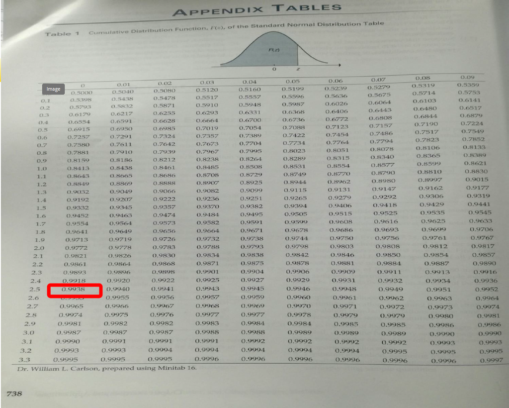

# Example 1 – light bulb lifetimes

### Problem solution using R

```r
# Population parameters and sample info
mu    <- 800   # Population mean (hours)
sigma <- 40    # Population standard deviation (hours)
n     <- 16    # Sample size
x_bar <- 775   # Observed sample mean

# Standard error of the mean:  SE = σ / √n
se <- sigma / sqrt(n)

# Convert sample mean to its Z‑score
#     Z = (x̄ − μ) / SE
z <- (x_bar - mu) / se      # Will be negative (775 < 800)

# Compute one‑tail probability
#     pnorm(z) gives  P(Z ≤ observed z)
prob <- pnorm(z)

#  Display results
list(
  Z_score    = round(z, 2),
  Probability_Xbar_below_775 = round(prob, 4)
)
```

```
## $Z_score
## [1] -2.5
##
## $Probability_Xbar_below_775
## [1] 0.0062
```

# Example 2 – between two values

### Problem overview

Suppose a large population has mean $\mu = 8$, and standard deviation $\sigma = 3$. Suppose a random sample of size $n = 36$ is selected.

> What is the probability that the sample mean is between 7.8 and 8.2 → $(P(7.8 \leq \bar{X} \leq 8.2)$?

# Example 2 – between two values

### Problem overview

Suppose a large population has mean $\mu = 8$, and standard deviation $\sigma = 3$. Suppose a random sample of size $n = 36$ is selected.

> What is the probability that the sample mean is between 7.8 and 8.2 → $(P(7.8 \leq \bar{X} \leq 8.2)$?

### Problem solution

We do not know whether the population is normally distributed, but sample size large enough to assume that CLT holds.

$$P(7.8< \bar{X}
<8.2)=P(\frac{7.8-8}{3/\sqrt{36}}<\frac{\bar{X}-\mu}{{\sigma}{/\sqrt{n}}}<\frac{8.2-8}{{3}{/\sqrt{36}}})
\\
P(-0.4<Z<0.4)=0.3108$$

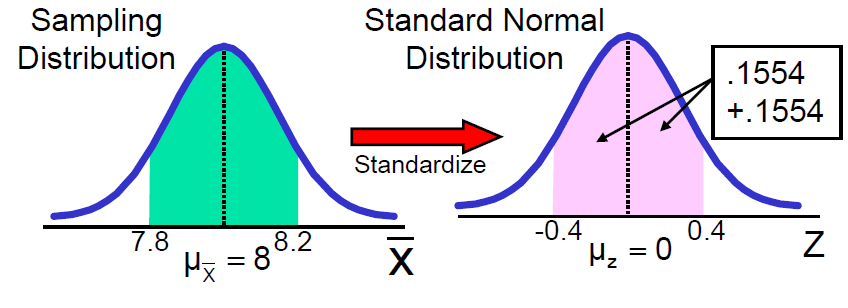

# Example 2 – between two values

### Using Standard Normal Table (textbook appendix)

So, if $Z= \pm 0.40$, from Z-table in the textbook appendix, then $P(Z < 0.40) = 0.6554$, and from symmetry: $P(Z < -0.40) = 0.3446$,

To get the probability: $P(-0.40 < Z < 0.40) = 0.6554 - 0.3446 = 0.3108$.

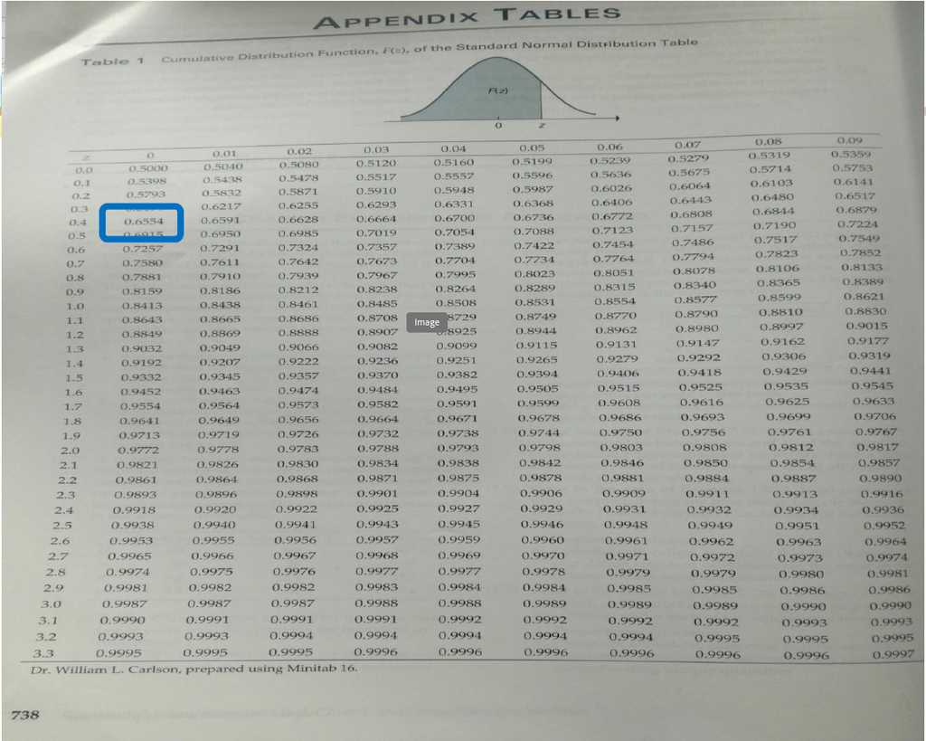

*(Highlighted values at Z = ±0.40)*

# Example 2 – between two values

### Problem solution using R

```r
# Parameters
mu <- 8         # Population mean
sigma <- 3      # Population standard deviation
n <- 36         # Sample size

# Step 1: Compute standard error (SE = σ / √n)
se <- sigma / sqrt(n)

# Step 2: Convert the bounds of the interval (7.8 and 8.2) to Z-scores
z_lower <- (7.8 - mu) / se     # Z for lower bound
z_upper <- (8.2 - mu) / se     # Z for upper bound

# Step 3: Compute probability that sample mean falls between 7.8 and 8.2
# This is P(7.8 < X̄ < 8.2) = P(Z_lower < Z < Z_upper)
prob <- pnorm(z_upper) - pnorm(z_lower)

# Step 4: Output Z-scores and final probability
list(Z_lower = z_lower, Z_upper = z_upper, Probability = prob)
```

```
## $Z_lower
## [1] -0.4
##
## $Z_upper
## [1] 0.4
##
## $Probability
## [1] 0.3108435
```

# Example 3 – Sample Proportions

### Problem overview

Population proportion $P = 0.4$ and sample size $n = 200$.

Find the probability that the sample proportion $\hat{p}$ is between 0.40 and 0.45; $P(0.40 \leq \hat{p} \leq 0.45)$

# Example 3 – Sample Proportions

### Problem overview

Population proportion $P = 0.4$ and sample size $n = 200$.

Find the probability that the sample proportion $\hat{p}$ is between 0.40 and 0.45; $P(0.40 \leq \hat{p} \leq 0.45)$

### Problem solution

We use the sampling distribution of the sample proportion $\hat{p} \sim N\left(P, \sqrt{P(1 - P)/n}\right)$

$$\sigma_{\hat{p}}= SE =\sqrt{\frac{P(1 - P)}{n}} = \sqrt{\frac{0.4 \cdot
0.6}{200}} \approx 0.0346$$
we convert the proportions 0.40 and 0.45 into **Z-scores** (standard normal):

$$Z = \frac{\hat{p} - P}{\sqrt{P(1 - P)/n}}$$
which gives us:
$$Z_{lower} = \frac{0.40 - 0.4}{0.0346} = 0.00 \\
Z_{upper} = \frac{0.45 - 0.4}{0.0346} \approx 1.44$$

# Example 3 – Sample Proportions

### Standard Normal Distribution

and from the z-table

- $Z = 0.00$ → $(P(Z < 0.00) = 0.5000)$
- $Z = 1.44$ → $(P(Z < 1.44) = 0.9251)$

So the probability between the two values is:
$$P(0.00 < Z < 1.44) = 0.9251 - 0.5000 = 0.4251$$

**Answer**: Probability = **0.4251**

### Distribution table

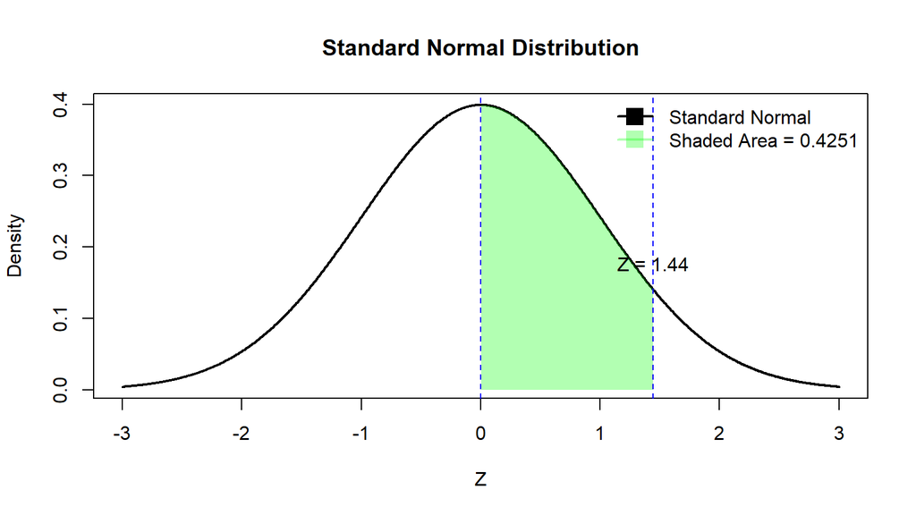

# Example 3 – Sample Proportions

### Problem solution using R

```r
# Define known values
P <- 0.4        # Population proportion
n <- 200        # Sample size

# Calculate standard error
se <- sqrt(P * (1 - P) / n)

# Calculate Z-scores for sample proportions 0.40 and 0.45
z_lower <- (0.40 - P) / se
z_upper <- (0.45 - P) / se

# Calculate probability using standard normal distribution
prob <- pnorm(z_upper) - pnorm(z_lower)

# Output results
list(
  Z_lower = round(z_lower, 2),
  Z_upper = round(z_upper, 2),
  Probability = round(prob, 4)
)
```

```
## $Z_lower
## [1] 0
##
## $Z_upper
## [1] 1.44
##
## $Probability
## [1] 0.4255
```